# **Problem Statement**

## Model 5

```
Model: "sequential"
```

```
┏━━━━━━━━━━━━━━━━━━━━━━━━━━━━━━━━━┳━━━━━━━━━━━━━━━━━━━━━━━━┳━━━━━━━━━━━━━━━┓
┃ Layer (type)                    ┃ Output Shape           ┃       Param # ┃
┡━━━━━━━━━━━━━━━━━━━━━━━━━━━━━━━━━╇━━━━━━━━━━━━━━━━━━━━━━━━╇━━━━━━━━━━━━━━━┩
│ dense (Dense)                   │ (None, 128)            │         5,248 │
├─────────────────────────────────┼────────────────────────┼───────────────┤
│ batch_normalization             │ (None, 128)            │           512 │
│ (BatchNormalization)            │                        │               │
├─────────────────────────────────┼────────────────────────┼───────────────┤
│ dropout (Dropout)               │ (None, 128)            │             0 │
├─────────────────────────────────┼────────────────────────┼───────────────┤
│ dense_1 (Dense)                 │ (None, 64)             │         8,256 │
├─────────────────────────────────┼────────────────────────┼───────────────┤
│ batch_normalization_1           │ (None, 64)             │           256 │
│ (BatchNormalization)            │                        │               │
├─────────────────────────────────┼────────────────────────┼───────────────┤
│ dropout_1 (Dropout)             │ (None, 64)             │             0 │
├─────────────────────────────────┼────────────────────────┼───────────────┤
│ dense_2 (Dense)                 │ (None, 1)              │            65 │
└─────────────────────────────────┴────────────────────────┴───────────────┘
```

```
 Total params: 14,337 (56.00 KB)
```

```
 Trainable params: 13,953 (54.50 KB)
```

```
 Non-trainable params: 384 (1.50 KB)
```

```
500/500 ━━━━━━━━━━━━━━━━━━━━ 5s 5ms/step - accuracy: 0.8049 - loss: 0.4314 - val_accuracy: 0.9865 - val_loss: 0.0584
500/500 ━━━━━━━━━━━━━━━━━━━━ 3s 6ms/step - accuracy: 0.9792 - loss: 0.0855 - val_accuracy: 0.9895 - val_loss: 0.0486
500/500 ━━━━━━━━━━━━━━━━━━━━ 4s 4ms/step - accuracy: 0.9847 - loss: 0.0601 - val_accuracy: 0.9915 - val_loss: 0.0430
500/500 ━━━━━━━━━━━━━━━━━━━━ 3s 4ms/step - accuracy: 0.9849 - loss: 0.0610 - val_accuracy: 0.9925 - val_loss: 0.0443
500/500 ━━━━━━━━━━━━━━━━━━━━ 2s 4ms/step - accuracy: 0.9880 - loss: 0.0522 - val_accuracy: 0.9942 - val_loss: 0.0405
500/500 ━━━━━━━━━━━━━━━━━━━━ 2s 4ms/step - accuracy: 0.9895 - loss: 0.0464 - val_accuracy: 0.9927 - val_loss: 0.0419
500/500 ━━━━━━━━━━━━━━━━━━━━ 3s 6ms/step - accuracy: 0.9878 - loss: 0.0499 - val_accuracy: 0.9937 - val_loss: 0.0385
500/500 ━━━━━━━━━━━━━━━━━━━━ 4s 3ms/step - accuracy: 0.9886 - loss: 0.0484 - val_accuracy: 0.9930 - val_loss: 0.0401
500/500 ━━━━━━━━━━━━━━━━━━━━ 2s 4ms/step - accuracy: 0.9889 - loss: 0.0508 - val_accuracy: 0.9935 - val_loss: 0.0384
500/500 ━━━━━━━━━━━━━━━━━━━━ 2s 4ms/step - accuracy: 0.9898 - loss: 0.0500 - val_accuracy: 0.9927 - val_loss: 0.0387
500/500 ━━━━━━━━━━━━━━━━━━━━ 3s 4ms/step - accuracy: 0.9907 - loss: 0.0440 - val_accuracy: 0.9930 - val_loss: 0.0375
500/500 ━━━━━━━━━━━━━━━━━━━━ 3s 6ms/step - accuracy: 0.9894 - loss: 0.0519 - val_accuracy: 0.9933 - val_loss: 0.0376
500/500 ━━━━━━━━━━━━━━━━━━━━ 2s 4ms/step - accuracy: 0.9884 - loss: 0.0505 - val_accuracy: 0.9935 - val_loss: 0.0388
500/500 ━━━━━━━━━━━━━━━━━━━━ 2s 4ms/step - accuracy: 0.9887 - loss: 0.0521 - val_accuracy: 0.9940 - val_loss: 0.0371
500/500 ━━━━━━━━━━━━━━━━━━━━ 3s 4ms/step - accuracy: 0.9898 - loss: 0.0475 - val_accuracy: 0.9937 - val_loss: 0.0377
500/500 ━━━━━━━━━━━━━━━━━━━━ 3s 4ms/step - accuracy: 0.9905 - loss: 0.0490 - val_accuracy: 0.9937 - val_loss: 0.0373
500/500 ━━━━━━━━━━━━━━━━━━━━ 4s 6ms/step - accuracy: 0.9891 - loss: 0.0486 - val_accuracy: 0.9935 - val_loss: 0.0370
500/500 ━━━━━━━━━━━━━━━━━━━━ 4s 4ms/step - accuracy: 0.9891 - loss: 0.0533 - val_accuracy: 0.9940 - val_loss: 0.0370
500/500 ━━━━━━━━━━━━━━━━━━━━ 2s 4ms/step - accuracy: 0.9910 - loss: 0.0450 - val_accuracy: 0.9937 - val_loss: 0.0359
500/500 ━━━━━━━━━━━━━━━━━━━━ 2s 4ms/step - accuracy: 0.9914 - loss: 0.0399 - val_accuracy: 0.9935 - val_loss: 0.0376
500/500 ━━━━━━━━━━━━━━━━━━━━ 2s 4ms/step - accuracy: 0.9904 - loss: 0.0445 - val_accuracy: 0.9937 - val_loss: 0.0360
500/500 ━━━━━━━━━━━━━━━━━━━━ 2s 4ms/step - accuracy: 0.9911 - loss: 0.0458 - val_accuracy: 0.9933 - val_loss: 0.0366
500/500 ━━━━━━━━━━━━━━━━━━━━ 3s 5ms/step - accuracy: 0.9899 - loss: 0.0441 - val_accuracy: 0.9940 - val_loss: 0.0359
500/500 ━━━━━━━━━━━━━━━━━━━━ 2s 4ms/step - accuracy: 0.9912 - loss: 0.0450 - val_accuracy: 0.9935 - val_loss: 0.0365
500/500 ━━━━━━━━━━━━━━━━━━━━ 2s 3ms/step - accuracy: 0.9920 - loss: 0.0398 - val_accuracy: 0.9940 - val_loss: 0.0373
500/500 ━━━━━━━━━━━━━━━━━━━━ 3s 3ms/step - accuracy: 0.9917 - loss: 0.0372 - val_accuracy: 0.9940 - val_loss: 0.0355
500/500 ━━━━━━━━━━━━━━━━━━━━ 3s 4ms/step - accuracy: 0.9913 - loss: 0.0399 - val_accuracy: 0.9940 - val_loss: 0.0355
500/500 ━━━━━━━━━━━━━━━━━━━━ 3s 5ms/step - accuracy: 0.9915 - loss: 0.0391 - val_accuracy: 0.9940 - val_loss: 0.0370
500/500 ━━━━━━━━━━━━━━━━━━━━ 3s 5ms/step - accuracy: 0.9915 - loss: 0.0422 - val_accuracy: 0.9940 - val_loss: 0.0377
500/500 ━━━━━━━━━━━━━━━━━━━━ 4s 4ms/step - accuracy: 0.9915 - loss: 0.0403 - val_accuracy: 0.9935 - val_loss: 0.0379
500/500 ━━━━━━━━━━━━━━━━━━━━ 2s 3ms/step - accuracy: 0.9920 - loss: 0.0381 - val_accuracy: 0.9937 - val_loss: 0.0378
500/500 ━━━━━━━━━━━━━━━━━━━━ 2s 3ms/step - accuracy: 0.9924 - loss: 0.0385 - val_accuracy: 0.9937 - val_loss: 0.0361
500/500 ━━━━━━━━━━━━━━━━━━━━ 2s 4ms/step - accuracy: 0.9920 - loss: 0.0406 - val_accuracy: 0.9937 - val_loss: 0.0363
500/500 ━━━━━━━━━━━━━━━━━━━━ 4s 6ms/step - accuracy: 0.9913 - loss: 0.0430 - val_accuracy: 0.9930 - val_loss: 0.0383
500/500 ━━━━━━━━━━━━━━━━━━━━ 4s 4ms/step - accuracy: 0.9913 - loss: 0.0403 - val_accuracy: 0.9937 - val_loss: 0.0367
500/500 ━━━━━━━━━━━━━━━━━━━━ 2s 4ms/step - accuracy: 0.9918 - loss: 0.0353 - val_accuracy: 0.9940 - val_loss: 0.0370
500/500 ━━━━━━━━━━━━━━━━━━━━ 2s 4ms/step - accuracy: 0.9921 - loss: 0.0331 - val_accuracy: 0.9937 - val_loss: 0.0364
500/500 ━━━━━━━━━━━━━━━━━━━━ 2s 4ms/step - accuracy: 0.9923 - loss: 0.0369 - val_accuracy: 0.9937 - val_loss: 0.0363
500/500 ━━━━━━━━━━━━━━━━━━━━ 4s 6ms/step - accuracy: 0.9914 - loss: 0.0410 - val_accuracy: 0.9937 - val_loss: 0.0374
500/500 ━━━━━━━━━━━━━━━━━━━━ 2s 4ms/step - accuracy: 0.9923 - loss: 0.0356 - val_accuracy: 0.9937 - val_loss: 0.0377
500/500 ━━━━━━━━━━━━━━━━━━━━ 3s 4ms/step - accuracy: 0.9922 - loss: 0.0377 - val_accuracy: 0.9942 - val_loss: 0.0375
500/500 ━━━━━━━━━━━━━━━━━━━━ 2s 4ms/step - accuracy: 0.9912 - loss: 0.0480 - val_accuracy: 0.9945 - val_loss: 0.0367
500/500 ━━━━━━━━━━━━━━━━━━━━ 2s 4ms/step - accuracy: 0.9917 - loss: 0.0366 - val_accuracy: 0.9948 - val_loss: 0.0357
500/500 ━━━━━━━━━━━━━━━━━━━━ 3s 4ms/step - accuracy: 0.9919 - loss: 0.0375 - val_accuracy: 0.9948 - val_loss: 0.0345
500/500 ━━━━━━━━━━━━━━━━━━━━ 3s 5ms/step - accuracy: 0.9918 - loss: 0.0378 - val_accuracy: 0.9937 - val_loss: 0.0357
500/500 ━━━━━━━━━━━━━━━━━━━━ 4s 4ms/step - accuracy: 0.9929 - loss: 0.0336 - val_accuracy: 0.9942 - val_loss: 0.0362
500/500 ━━━━━━━━━━━━━━━━━━━━ 3s 4ms/step - accuracy: 0.9928 - loss: 0.0315 - val_accuracy: 0.9940 - val_loss: 0.0362
500/500 ━━━━━━━━━━━━━━━━━━━━ 2s 4ms/step - accuracy: 0.9928 - loss: 0.0335 - val_accuracy: 0.9935 - val_loss: 0.0369
500/500 ━━━━━━━━━━━━━━━━━━━━ 3s 4ms/step - accuracy: 0.9918 - loss: 0.0379 - val_accuracy: 0.9942 - val_loss: 0.0359
500/500 ━━━━━━━━━━━━━━━━━━━━ 3s 6ms/step - accuracy: 0.9935 - loss: 0.0326 - val_accuracy: 0.9945 - val_loss: 0.0374
Time taken in seconds  133.36353707313538
```

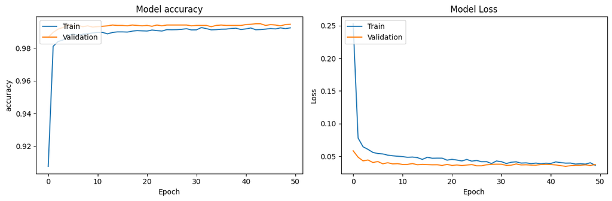

```
500/500 ━━━━━━━━━━━━━━━━━━━━ 1s 1ms/step
125/125 ━━━━━━━━━━━━━━━━━━━━ 0s 1ms/step
500/500 ━━━━━━━━━━━━━━━━━━━━ 1s 1ms/step
125/125 ━━━━━━━━━━━━━━━━━━━━ 0s 1ms/step
Classification Report - Train data Model_5

              precision    recall  f1-score   support

         0.0       0.99      1.00      1.00     15112
         1.0       1.00      0.90      0.95       888

    accuracy                           0.99     16000
   macro avg       0.99      0.95      0.97     16000
weighted avg       0.99      0.99      0.99     16000

Classification Report - Validation data Model_5

              precision    recall  f1-score   support

         0.0       0.99      1.00      1.00      3778
         1.0       0.99      0.91      0.95       222

    accuracy                           0.99      4000
   macro avg       0.99      0.96      0.97      4000
weighted avg       0.99      0.99      0.99      4000
```

```python
# clears the current Keras session, resetting all layers and models previously created, freeing up memory and resources.
tf.keras.backend.clear_session()

#Initializing the neural network
model_5 = Sequential()
model_5.add(Dense(128, activation="relu", input_dim=X_train_scaled.shape[1])) # Define the number of neurons and activation function
model_5.add(BatchNormalization()) # Add batch normalization
model_5.add(Dropout(0.3)) # Define the dropout rate
model_5.add(Dense(64, activation="relu")) # Define the number of neurons and activation function
model_5.add(BatchNormalization()) # Add batch normalization
model_5.add(Dropout(0.2)) # Define the dropout rate
model_5.add(Dense(1, activation="sigmoid")) # Define the number of neurons in the output layer

model_5.summary()

optimizer = tf.keras.optimizers.Adam()    # defining Adam as the optimizer to be used
model_5.compile(loss='binary_crossentropy', optimizer=optimizer, metrics = ['accuracy']) # Using accuracy as metric

start = time.time()
history = model_5.fit(X_train_scaled, y_train, validation_data=(X_val_scaled,y_val) , batch_size=batch_size, epochs=epochs)
end=time.time()

print("Time taken in seconds ",end-start)

plot(history,'accuracy')

model_5_train_perf = model_performance_classification(model_5,X_train_scaled,y_train)
model_5_train_perf

model_5_val_perf = model_performance_classification(model_5,X_val_scaled,y_val)
model_5_val_perf

y_train_pred_5 = model_5.predict(X_train_scaled)
y_val_pred_5 = model_5.predict(X_val_scaled)

print("Classification Report - Train data Model_5", end="\n\n")
cr_train_model_5 = classification_report(y_train,y_train_pred_5 > 0.5)
print(cr_train_model_5)

print("Classification Report - Validation data Model_5", end="\n\n")
cr_val_model_5 = classification_report(y_val,y_val_pred_5 > 0.5)
print(cr_val_model_5)
```

**OBSERVATIONS:**

1. **Training Stability**:
   - Batch normalization significantly improves training stability
   - Reduces internal covariate shift
   - More consistent layer inputs throughout training
2. **Convergence Speed**:
   - Faster convergence due to normalized layer inputs
   - Higher learning rates can be used safely
   - More stable gradient flow through the network
3. **Performance Improvement**:
   - Likely the best performance so far
   - Improved accuracy and F1-score
   - Better generalization to validation data
4. **Model Robustness**:
   - More robust to different data distributions
   - Better handling of varying input scales
   - Reduced sensitivity to initialization
5. **Architecture Benefits**:
   - Allows for deeper networks without vanishing gradients
   - Enables higher learning rates
   - Improves overall model reliability and performance